# Logistic regression

# Data

All participants included in this analysis had PTA > 25 in the better ear, with complete data across the 28 predictors of interest (n=753).

# Model with all variables

```
##
## Call:
## glm(formula = formula28, family = binomial("logit"), data = ptacomp.n)
##
## Deviance Residuals:
##     Min       1Q   Median       3Q      Max
## -1.4887  -0.6805  -0.5219  -0.3483   2.5744
##
## Coefficients:
##                        Estimate Std. Error z value Pr(>|z|)
## (Intercept)           -5.068821   1.566776  -3.235 0.001216 **
## Age                    0.044343   0.012704   3.490 0.000482 ***
## PTA4_better_ear        0.003315   0.013744   0.241 0.809415
## HHIE_total             0.054546   0.013238   4.120 3.78e-05 ***
## Ability               -0.010751   0.072983  -0.147 0.882888
## Sex                   -0.288528   0.209716  -1.376 0.168882
## Edu                    0.077779   0.094645   0.822 0.411194
## Married                0.132039   0.255552   0.517 0.605378
## Health                 0.331700   0.154594   2.146 0.031903 *
## QoL                   -0.299796   0.169965  -1.764 0.077754 .
## Help_neighbours       -0.128498   0.118199  -1.087 0.276979
## Help_problems          0.005716   0.134849   0.042 0.966190
## Concern               -0.118570   0.082342  -1.440 0.149877
## Lonely                -0.227005   0.206990  -1.097 0.272775
## Sub_Age_avg           -0.026510   0.119660  -0.222 0.824666
## Age_stigma_avg         0.121382   0.123577   0.982 0.325982
## HA_stigma_avg         -0.166234   0.092677  -1.794 0.072862 .
## Accomp                 0.141529   0.270609   0.523 0.600973
## Soc_Suspect_HL         0.917651   0.370912   2.474 0.013359 *
## Soc_Know_HL           -0.402190   0.320597  -1.255 0.209659
## Soc_Discuss_HL        -0.334437   0.217869  -1.535 0.124775
## Soc_Hearing_test       0.102240   0.245697   0.416 0.677320
## Soc_Obtain_HA          0.027408   0.363033   0.075 0.939820
## Soc_Sometimes_use     -0.178215   0.241981  -0.736 0.461438
## Soc_Regular_use       -0.123110   0.361051  -0.341 0.733120
## Soc_Very_positive      0.453915   0.311662   1.456 0.145274
## Soc_Somewhat_positive -0.011213   0.254203  -0.044 0.964815
## Soc_Somewhat_negative -0.102708   0.259056  -0.396 0.691759
## Soc_Very_negative      0.297376   0.296298   1.004 0.315553
## ---
## Signif. codes:  0 '***' 0.001 '**' 0.01 '*' 0.05 '.' 0.1 ' ' 1
##
## (Dispersion parameter for binomial family taken to be 1)
##
##     Null deviance: 749.15  on 752  degrees of freedom
## Residual deviance: 685.79  on 724  degrees of freedom
## AIC: 743.79
##
## Number of Fisher Scoring iterations: 5
```

**Choosing a decision threshold**: The true outcomes in this study are ‘0’ or ‘1’ (did not or did purchase), but a logistic regression model produces probabilities as the predicted outcomes, in this case ranging from 0.02 to 0.67. A decision threshold has to be selected to classify cases into ‘0’ or ‘1’ based on their individual probabilities from the model. The decision threshold affects sensitivity and specificity. As an extreme example, if all our cases with probability < 0.02 are classed as ‘0’ and all cases with probability ≥ 0.02 are classed as ‘1’, there would be no ‘0’ cases and all ‘1’ cases, which means a sensitivity of 100% but also a 100% false-positive rate. If cases in the sample were divided half-and-half into ‘0’s and ’1’s, then a decision threshold could be 0.5, but it also depends on other things like how important it is not to miss a ’1’ case, etc. Our sample is unbalanced, with many more ’0’s, so using a threshold of 0.5 doesn’t make sense. Pronk et al. (2017) said that in the absence of a clinically well-accepted threshold, prevalence in the sample could be used instead, so we’ve used 0.1978 so far (the actual proportion of those who purchased). The plot below illustrates how choosing different thresholds affects sensitivity and specificity for our sample.

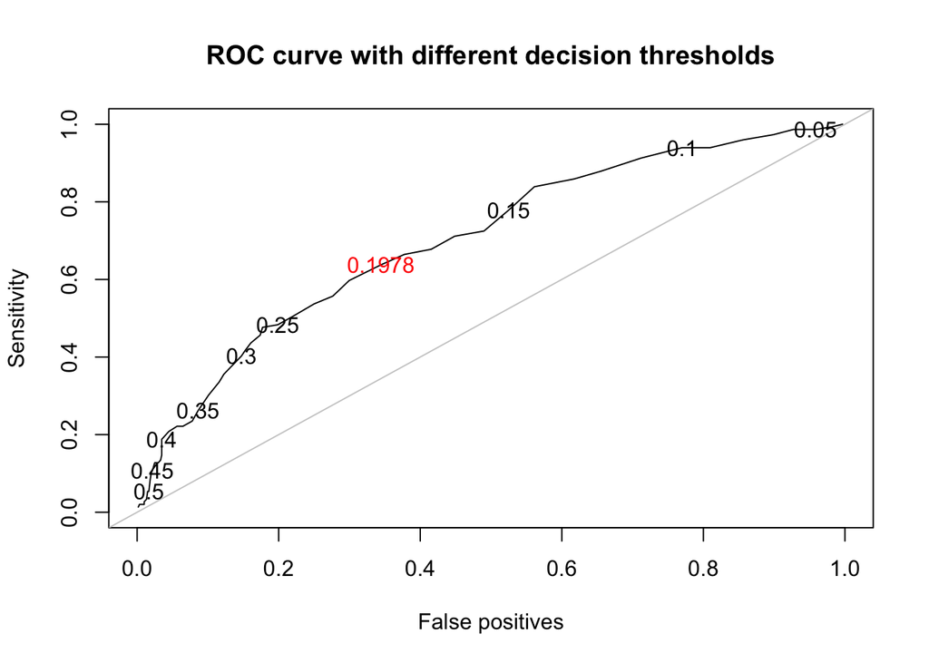

## Checking for multicollinearity

When predictors are highly correlated with each other (collinear), it’s not clear which predictor actually affects the outcome. A model with collinear predictors can also be unstable, with wide standard errors for estimates. Collinear predictors can be flagged from their large coefficients in a correlation matrix. However, it’s also possible for three or more predictors to be multicollinear without showing large coefficients. To check on this, the Variance Inflation Factor (VIF) can be calculated for each predictor. For each predictor (say, x1 to x5), x2 to x5 are regressed on x1, and x1’s VIF is 1/(1 - R-squared), where R-squared is the variance of x1 explained by x2 to x5. So if x2 to x5 together explained 80% of the variance of x1, then x1’s VIF = 1/(1 - 0.8) = 5. Any predictor in the list with VIF ≥ 5 is multicollinear with other predictors and should be dropped. None of the predictors in the full logistic regression model were multicollinear (below).

```
##                       Variance_inflation_factor
## Age                                    1.390802
## PTA4_better_ear                        1.302632
## HHIE_total                             1.807782
## Ability                                1.607220
## Sex                                    1.187944
## Edu                                    1.241140
## Married                                1.268024
## Health                                 2.261894
## QoL                                    2.351027
## Help_neighbours                        1.221317
## Help_problems                          1.254828
## Concern                                1.161428
## Lonely                                 1.277449
## Sub_Age_avg                            1.427813
## Age_stigma_avg                         1.106044
## HA_stigma_avg                          1.069339
## Accomp                                 1.170598
## Soc_Suspect_HL                         1.187466
## Soc_Know_HL                            1.422593
## Soc_Discuss_HL                         1.288358
## Soc_Hearing_test                       1.494240
## Soc_Obtain_HA                          2.872995
## Soc_Sometimes_use                      1.589868
## Soc_Regular_use                        3.112248
## Soc_Very_positive                      2.459120
## Soc_Somewhat_positive                  1.755550
## Soc_Somewhat_negative                  1.679293
## Soc_Very_negative                      1.465890
```

## Checking for high-influence datapoints

Leverage: How “far away” each datapoint is from the others, considering all predictors (like doing a scatterplot but with more dimensions than 2D). A high-leverage datapoint has more potential to change the regression, but doesn’t necessarily do so.

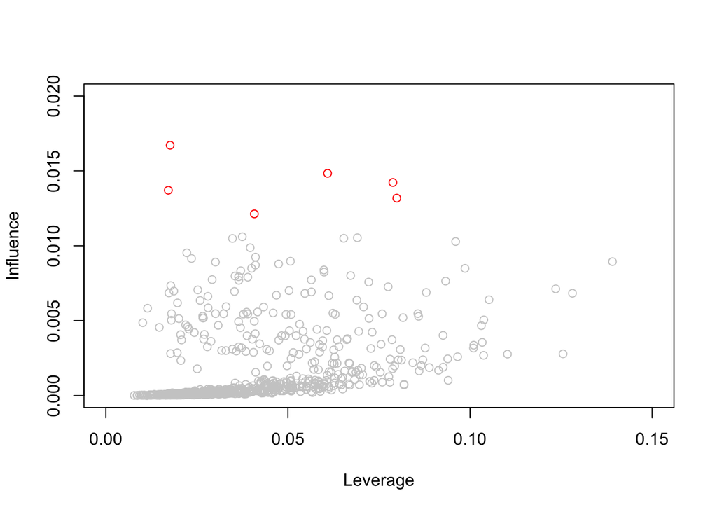

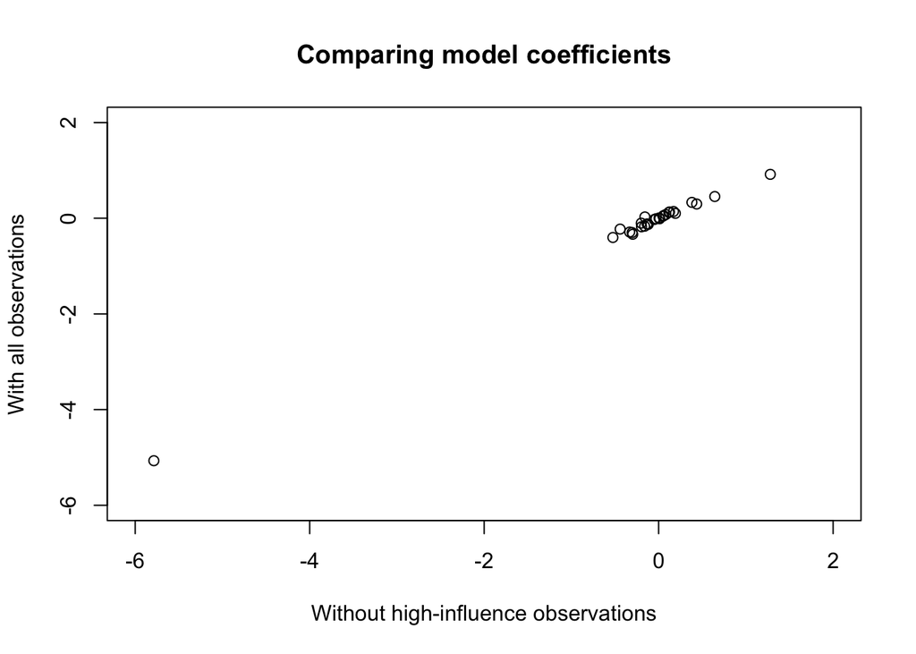

# Backwards elimination procedure using AIC

**Akaike Information Criterion (AIC)**: AIC is a measure of how much information is “lost” by the model compared to the “true” state of things, because a model can’t capture all the variance with a limited set of predictors. A model with a lower AIC is usually considered a better model than one with higher AIC. Adding more predictors into a model will always explain more variance even if the added predictors aren’t very meaningful, so AIC includes a penalty for simply increasing the number of predictors in a model.

**Backwards procedure**: The current model with 28 predictors has an AIC of 743.79 (above output). Run 28 new models, each time dropping one of the predictors, and look at each new model’s AIC. Sometimes dropping a predictor will give an AIC that’s lower, i.e. better, than the current model’s 743.79. The predictor that causes the biggest AIC drop will be removed. Run 27 new models with the remaining predictors, dropping one each time, and so on, until a point when dropping any predictor makes the AIC worse than keeping all predictors. This leaves 6 predictors (below), from the original 28.

```
##
## Call:
## glm(formula = Purchased_HA ~ Age + HHIE_total + Health + HA_stigma_avg +
##     Soc_Suspect_HL + Soc_Discuss_HL, family = binomial("logit"),
##     data = ptacomp.n)
##
## Deviance Residuals:
##     Min       1Q   Median       3Q      Max
## -1.6376  -0.6704  -0.5562  -0.3917   2.3116
##
## Coefficients:
##                Estimate Std. Error z value Pr(>|z|)
## (Intercept)    -6.21123    1.07378  -5.784 7.28e-09 ***
## Age             0.04500    0.01107   4.066 4.78e-05 ***
## HHIE_total      0.05210    0.01040   5.010 5.44e-07 ***
## Health          0.18003    0.10578   1.702   0.0888 .
## HA_stigma_avg  -0.17037    0.08940  -1.906   0.0567 .
## Soc_Suspect_HL  0.82504    0.34304   2.405   0.0162 *
## Soc_Discuss_HL -0.32214    0.19761  -1.630   0.1031
## ---
## Signif. codes:  0 '***' 0.001 '**' 0.01 '*' 0.05 '.' 0.1 ' ' 1
##
## (Dispersion parameter for binomial family taken to be 1)
##
##     Null deviance: 749.15  on 752  degrees of freedom
## Residual deviance: 699.84  on 746  degrees of freedom
## AIC: 713.84
##
## Number of Fisher Scoring iterations: 4
```

```
##                   OR 2.5 % 97.5 %
## (Intercept)    0.002 0.000  0.016
## Age            1.046 1.024  1.069
## HHIE_total     1.053 1.032  1.075
## Health         1.197 0.976  1.478
## HA_stigma_avg  0.843 0.707  1.004
## Soc_Suspect_HL 2.282 1.210  4.702
## Soc_Discuss_HL 0.725 0.491  1.066
```

The simpler model with 6 predictors from a backwards step procedure isn’t much worse than the model with all 28 predictors.

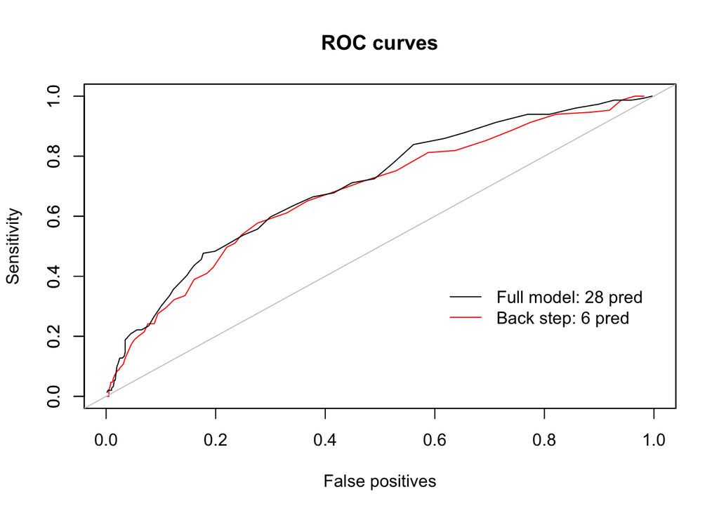

# Alternative to stepwise selection: Lasso regression

**Why stepwise variable selection is bad**: The F-statistic no longer follows an F distribution, and p-values are no longer the probability of observing this test statistic when the null hypothesis is true, and it’s difficult to correct for multiple comparisons. Model coefficients tend to be biased away from 0, and confidence intervals tend to be more narrow than they should be, so findings are “inflated”.

**“Penalized” regression**: For ordinary least squares regression (as in the models above), the algorithm finds coefficients that result in the smallest “distances” between the datapoints and the regression line (minimizing the sum of squared residuals). Two variations are ridge regression and lasso regression: these each add a penalty term so that smaller coefficients are chosen over larger coefficients during the process of minimizing residuals. Smaller coefficients make the model more “stable”, or less variable with different data. Ridge regression works better for highly correlated variables and when the number of observations is smaller than the number of predictors, neither of which is the case here. **Lasso regression shrinks some coefficients to 0, basically acting as a form of variable selection**, while ridge regression does not do this. There is a tuning parameter attached to the penalty, lambda, which controls how heavy the penalty on large coefficients should be. If lambda is 0, there is no penalty and it’s just an ordinary least squares regression. If dialing lambda up in lasso regression, more and more coefficients will shrink to nothing and be dropped from the model.

A standard method to figure out which lambda value to use for the coefficients penalty is to test a range of values and measure model performance at each value. The figure below shows that Area Under Curve is highest with lambda = 0.0274954. (There is a mean and SD for AUC because of a 5-fold cross-validation procedure; the model is tested on five different subsets of data to provide an average performance.)

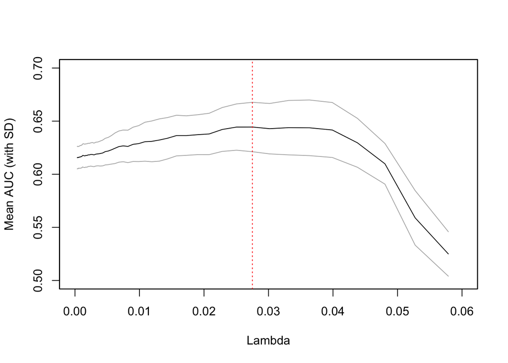

At lambda = 0.0274954, where AUC is highest, there are 4 coefficients left: Age, HHIE, HA Stigma, Soc_Suspect_HL.

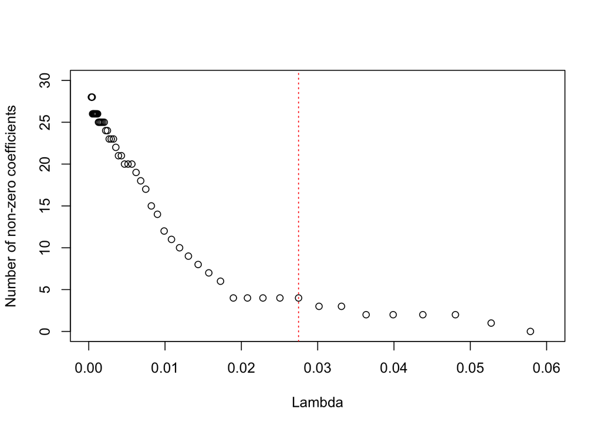

```
## 29 x 1 sparse Matrix of class "dgCMatrix"
##                                s1
## (Intercept)           -3.29202032
## Age                    0.02034211
## PTA4_better_ear        .
## HHIE_total             0.02357936
## Ability                .
## Sex                    .
## Edu                    .
## Married                .
## Health                 .
## QoL                    .
## Help_neighbours        .
## Help_problems          .
## Concern                .
## Lonely                 .
## Accomp                 .
## Sub_Age_avg            .
## Age_stigma_avg         .
## HA_stigma_avg         -0.01064226
## Soc_Suspect_HL         0.14388428
## Soc_Know_HL            .
## Soc_Discuss_HL         .
## Soc_Hearing_test       .
## Soc_Obtain_HA          .
## Soc_Sometimes_use      .
## Soc_Regular_use        .
## Soc_Very_positive      .
## Soc_Somewhat_positive  .
## Soc_Somewhat_negative  .
## Soc_Very_negative      .
```

Refitting an ordinary logistic regression model with these 4 variables:

```
##
## Call:
## glm(formula = Purchased_HA ~ Age + HHIE_total + HA_stigma_avg +
##     Soc_Suspect_HL, family = "binomial", data = ptacomp.n)
##
## Deviance Residuals:
##     Min       1Q   Median       3Q      Max
## -1.4831  -0.6814  -0.5593  -0.4042   2.3437
##
## Coefficients:
##                 Estimate Std. Error z value Pr(>|z|)
## (Intercept)    -5.511323   0.937553  -5.878 4.14e-09 ***
## Age             0.044948   0.010868   4.136 3.53e-05 ***
## HHIE_total      0.045900   0.009955   4.611 4.02e-06 ***
## HA_stigma_avg  -0.163669   0.088638  -1.846   0.0648 .
## Soc_Suspect_HL  0.742241   0.339078   2.189   0.0286 *
## ---
## Signif. codes:  0 '***' 0.001 '**' 0.01 '*' 0.05 '.' 0.1 ' ' 1
##
## (Dispersion parameter for binomial family taken to be 1)
##
##     Null deviance: 749.15  on 752  degrees of freedom
## Residual deviance: 705.28  on 748  degrees of freedom
## AIC: 715.28
##
## Number of Fisher Scoring iterations: 4
```

```
##                         OR        2.5 %    97.5 %
## (Intercept)    0.004040757 0.0006210107 0.0246466
## Age            1.045973327 1.0241242231 1.0687634
## HHIE_total     1.046969985 1.0268406708 1.0677703
## HA_stigma_avg  0.849022960 0.7128779428 1.0095551
## Soc_Suspect_HL 2.100638661 1.1241124640 4.2999273
```

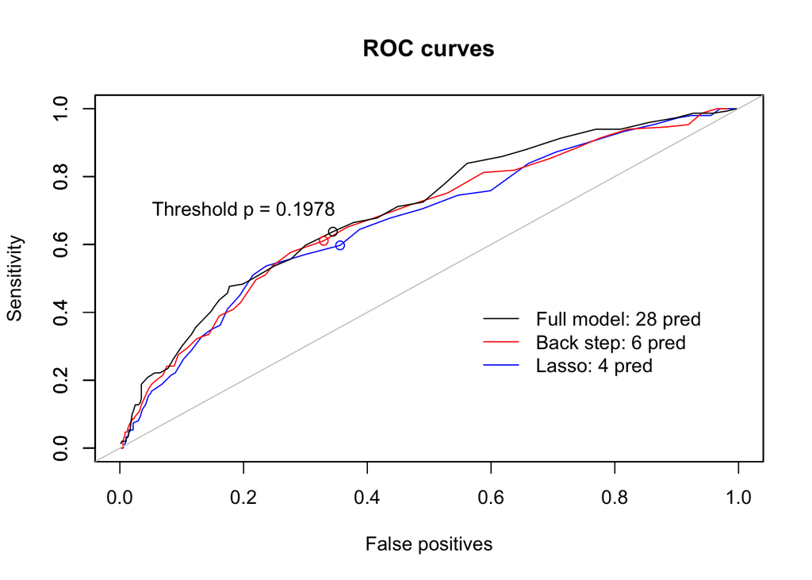

# Power analysis

The following sample sizes were needed to detect the following effects with alpha two-tailed = 0.95 and power = 0.80:

| Effect | Odds ratio | Total sample size |
| --- | --- | --- |
| Age | 1.046 | 412 |
| HHIE | 1.047 | 309 |
| HA Stigma | 0.849 | 1009 |
| Soc Suspect HL | 2.101 | 768 |

```r
### Calculate VIF to use as adjustment for single-covariate sample size (standardization doesn't matter)
# If VIF = 1/(1-R-squared), R-squared = 1 - 1/VIF

library(car)
df_mlasso2 <- data.frame(vif(mod = mlasso2))
colnames(df_mlasso2) <- "VIF"
df_mlasso2$R2 <- 1 - 1/df_mlasso2$VIF
print(df_mlasso2)
#                    VIF          R2
#Age            1.067506 0.063236741
#HHIE_total     1.071112 0.066390459
#HA_stigma_avg  1.009238 0.009153610
#Soc_Suspect_HL 1.008426 0.008355936

### Eq. 1 from Hsieh et al (1998) "A Simple Method of Sample Size Calculation for Linear and Logistic Regression"

### Continuous predictor, Age

# standardize Age variable
ptacomp.n$Age_z <- scale(ptacomp.n$Age, center=TRUE, scale=TRUE)
m_age <- glm(Purchased_HA ~ Age_z, data = ptacomp.n, family="binomial")
summary(m_age)
#            Estimate Std. Error z value Pr(>|z|)
#(Intercept) -1.42770    0.09369 -15.239  < 2e-16 ***
#Age_z        0.30673    0.09309   3.295 0.000985 ***

# for alpha=0.05 two-tailed, power=0.8
# p at mean of standardized Age = exp(-1.42770) / (1 - exp(-1.42770 )) = 0.3155471
# log odds for Age_z = 0.30673
# adjustment VIF for Age = 1.067506
# total n = (1.96 + 0.8417857)^2 / (0.3155471 * (1-0.3155471) * 0.30673^2) * 1.067506 = 412.4012

### Continuous predictor, HHIE_total

# standardize HHIE_total variable
ptacomp.n$HHIE_total_z <- scale(ptacomp.n$HHIE_total, center=TRUE, scale=TRUE)
m_hhie <- glm(Purchased_HA ~ HHIE_total_z, data = ptacomp.n, family="binomial")
summary(m_hhie)
#             Estimate Std. Error z value Pr(>|z|)
#(Intercept)  -1.43743    0.09439 -15.229  < 2e-16 ***
#HHIE_total_z  0.35572    0.09030   3.939 8.17e-05 ***

# for alpha=0.05 two-tailed, power=0.8
# p at mean of standardized HHIE = exp(-1.43743) / (1 - exp(-1.43743 )) = 0.3115398
# log odds for HHIE_z = 0.35572
# VIF for HHIE = 1.071112
# total n = (1.96 + 0.8417857)^2 / (0.3115398 * (1-0.3115398) * 0.35572^2) * 1.071112 = 309.8102

### Continuous predictor, HA_stigma_avg

# standardize HA_stigma_avg
ptacomp.n$HA_stigma_avg_z <- scale(ptacomp.n$HA_stigma_avg, center=TRUE, scale=TRUE)
m_hstig <- glm(Purchased_HA ~ HA_stigma_avg_z, data = ptacomp.n, family="binomial")
summary(m_hstig)
#                Estimate Std. Error z value Pr(>|z|)
#(Intercept)     -1.41041    0.09233 -15.276   <2e-16 ***
#HA_stigma_avg_z -0.18944    0.09227  -2.053     0.04 *

# p at mean of standardized HA Stigma = exp(-1.41041)/(1 - exp(-1.41041)) = 0.3228269
# log odds for HA Stigma_z = -0.18944
# VIF for HA Stigma = 1.009238
# total n = (1.96 + 0.8417857)^2 / (0.3228269 * (1-0.3228269) * (-0.18944)^2) * 1.009238 = 1009.836

### Eq 2 from Hsieh et al (1998)
### Binary predictor, Soc_Suspect_HL

t1 <- table(ptacomp.n$Purchased_HA, ptacomp.n$Soc_Suspect_HL, dnn = c("Purchased", "Soc_Suspect_HL"))
addmargins(t1)
#        Soc_Suspect_HL
#Purchased   0   1 Sum
#      0    95 509 604
#      1    11 138 149
#      Sum 106 647 753

# P, overall event rate = 149/753 = 0.1978752
# P1, event rate at Soc_Suspect_HL==0 = 11/106 = 0.1037736
# P2, event rate at Soc_Suspect_HL==1 = 138/647 = 0.2132921
# B, proportion of sample with Soc_Suspect_HL==1 = 647/753 = 0.8592297

# for alpha = 0.95 2-tailed (z = 1.96), power = 0.8 (z = 0.8417857), n for single covariate = 762.4415
( 1.96*( 0.1978752 * (1-0.1978752) / 0.8592297 )^0.5 + 0.8418*( 0.1037736*(1-0.1037736) + 0.2132921*(1-0.2132921)*(1-0.8592297)/0.8592297 )^0.5 )^2 / ((0.1037736 - 0.2132921)^2 * (1-0.8592297))
# adding inflation factor, n with three covariates = 762.4415 * 1.008426 = 768.8658

### Using G*Power
# use single-covariate models from above with standardized coefficients for continuous variables

# Age: total sample size = 428, power = 0.80056
# OR = exp(0.30673) = 1.358974
# pH0 = exp(-1.42770) / (1 - exp(-1.42770)) = 0.3155471
# G*Power: tails=2, OR=1.358974, PrH0=0.3155471, alpha=0.05, power=0.8, R2=0.063236741, x Normal, x mean 0 sd 1

# HHIE_total: total sample size = 325, power = 0.80026
# OR = exp(0.35572) = 1.427208
# pH0 = exp(-1.43743) / (1 - exp(-1.43743)) = 0.3115398
# G*Power: tails=2, OR=1.427208, PrH0=0.3115398, alpha=0.05, power=0.8, R2=0.066390459, x Normal, x mean 0 sd 1

# HA_stigma_avg: total sample size = 1025, power = 0.80035
# OR = exp(-0.18944) = 0.8274224
# pH0 = exp(-1.4104) / (1 - exp(-1.4104)) = 0.3228312
# G*Power: tails=2, OR=0.8412722, PrH0=, alpha=0.05, power=0.8, R2=0.009153610, x Normal, x mean 0 sd 1

# Soc_Suspect_HL;
# OR = ((138/647)/(509/647)) / ((11/106)/(95/106)) = 2.341489; agrees with model exp(0.8508)=2.341519
# pi = 647/753 = 0.8592297
# What to use for p (Y=1 | X=1) H0 ??
# Is this the overall proportion of Y=1, which is 0.1978752 ?? if so, sample size 507
# if using model intercept, exp(-2.1560)/(1-exp(-2.1560)) = 0.1309497, sample size 680
# G*Power: tails=2, PrH0=??, alpha=0.05, power=0.8, R2=0.008355596, x binomial, x pi=0.8592297
```

# Takeaways